# Reproducible Research - Assignment 1

# Are there differences in activity patterns between weekdays and weekends?

##### 1. Create a new factor variable in the dataset with two levels – “weekday” and “weekend” indicating whether a given date is a weekday or weekend day.

```r
fdata$whichday <-  ifelse(as.POSIXlt(as.Date(fdata$date))$wday %in% c(0,6), 'weekend', 'weekday')

fdataInterval <- aggregate(steps ~ interval + whichday, data=fdata, mean)
```

##### 2. Make a panel plot containing a time series plot of the 5-minute interval (x-axis) and the average number of steps taken, averaged across all weekday days or weekend days (y-axis). See the README file in the GitHub repository to see an example of what this plot should look like using simulated data.

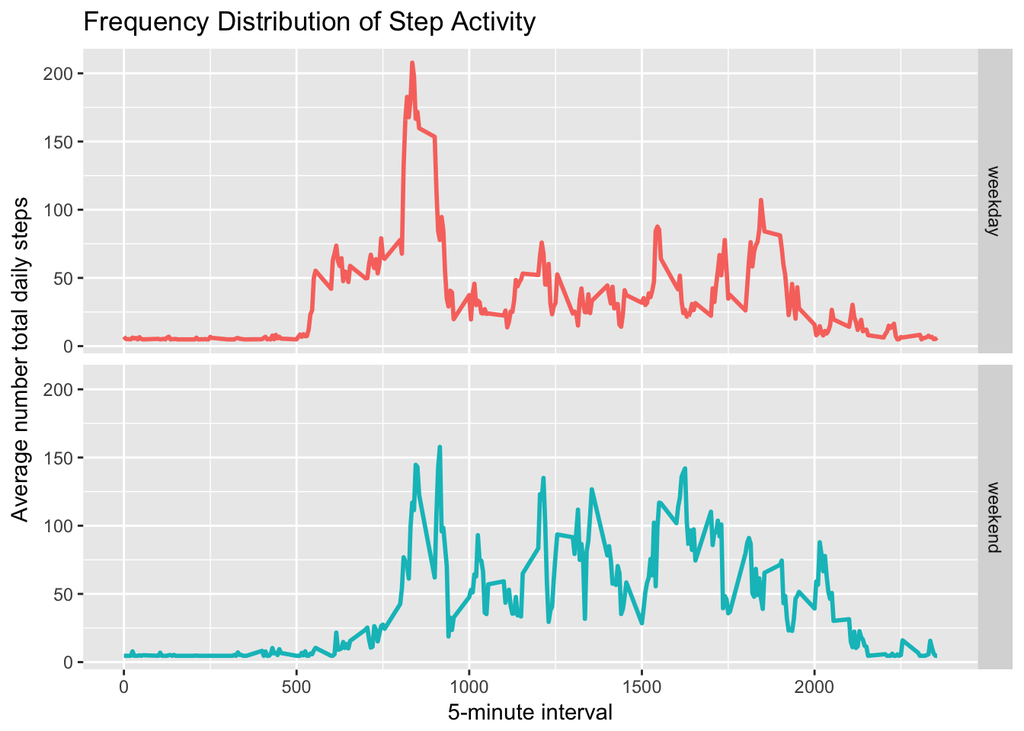

```r
ggplot(fdataInterval, aes(interval, steps, colour=whichday)) +
geom_line(linetype="solid", size=1.0) +
facet_grid(whichday ~ .) +
labs(title = "Frequency Distribution of Step Activity",
          x="5-minute interval",
          y="Average number total daily steps") +
theme(legend.position="none")
```

We see in the plot above that the weekeday activity occurs mostly in the morning (there’s a peak around 8 to 9 AM). Though both weekday and weekend shows this peak, we see this effect is more accentuated during the week, while the average activity is more spread out on weekends.